# BSG Statistical Genetics practical 5

Biel and Gerard

2023-12-16

## 1. Load the YRI06.raw file into the R environment. How many individuals and how many SNPs are there in the database? What percentage of the data is missing?

```r
library(data.table)
library(gdsfmt)
library(SNPRelate)
data <- fread("YRI6.raw")
alleles <- data[,7:ncol(data)]
dataDim <- dim(alleles)

print(paste0("In there dataset the are ", dataDim[1]," individuals and ", dataDim[2], " SNPs."))
```

```
## [1] "In there dataset the are 84 individuals and 56574 SNPs."
```

```r
print(paste0("The parcentage of missing data is ", (sum(is.na(data))/(dataDim[1]*dataDim[2]))*100,"%"))
```

```
## [1] "The parcentage of missing data is 0%"
```

## 2. Compute, for each pair of individuals (and report the first 5), the mean m of the number of alleles shared and the standard deviation s of the number of alleles shared.

```r
share <- function(col){
  if(col[1] %in% c(0,2)){
    if(col[1]==col[2]){
      return(2)
    } else if(col[2]==1){
      return(1)
    }
  } else if(col[1]==1){
    if(col[2] %in% c(0,2)){
      return(1)
    } else {return(2)}
  }
  return(0)
}

vector_m <- c()
vector_s <- c()
numAlleles <- ncol(alleles)
for(i in 1:(nrow(alleles)-1)){
  ind1 <- alleles[i,]
  for(j in (i+1):nrow(alleles)){
    ind2 <- alleles[j,]

    allelesShared <- apply(rbind(ind1,ind2),2,FUN=share)
    mean <- sum(allelesShared)/numAlleles
    s <- (sum((allelesShared-mean)**2))/(numAlleles-1)

    vector_s <- append(vector_s,s)
    vector_m <- append(vector_m,mean)

  }
}
vector_s[1:5]
```

```
## [1] 0.4381026 0.4377357 0.4399613 0.4370415 0.4364323
```

```r
vector_m[1:5]
```

```
## [1] 1.248701 1.245113 1.247198 1.246668 1.245608
```

```r
vector_p0 <- c()
vector_p2 <- c()

for(i in 1:(nrow(alleles)-1)){
  ind1 <- alleles[i,]
  for(j in (i+1):nrow(alleles)){
    ind2 <- alleles[j,]

    allelesShared <- apply(rbind(ind1,ind2),2,FUN=share)

    vector_0 <- sum(allelesShared == 0)
    vector_2 <- sum(allelesShared == 2)

    vector_p0 <- append(vector_p0,vector_0/numAlleles)
    vector_p2 <- append(vector_p2,vector_2/numAlleles)
  }
}

vector_p0[1:5]
```

```
## [1] 0.1256231 0.1263478 0.1269311 0.1256054 0.1255700
```

```r
vector_p2[1:5]
```

```
## [1] 0.3743239 0.3714604 0.3741295 0.3722735 0.3711776
```

## 4.Plot m against s and plot p0 against p2. Comment on the results.

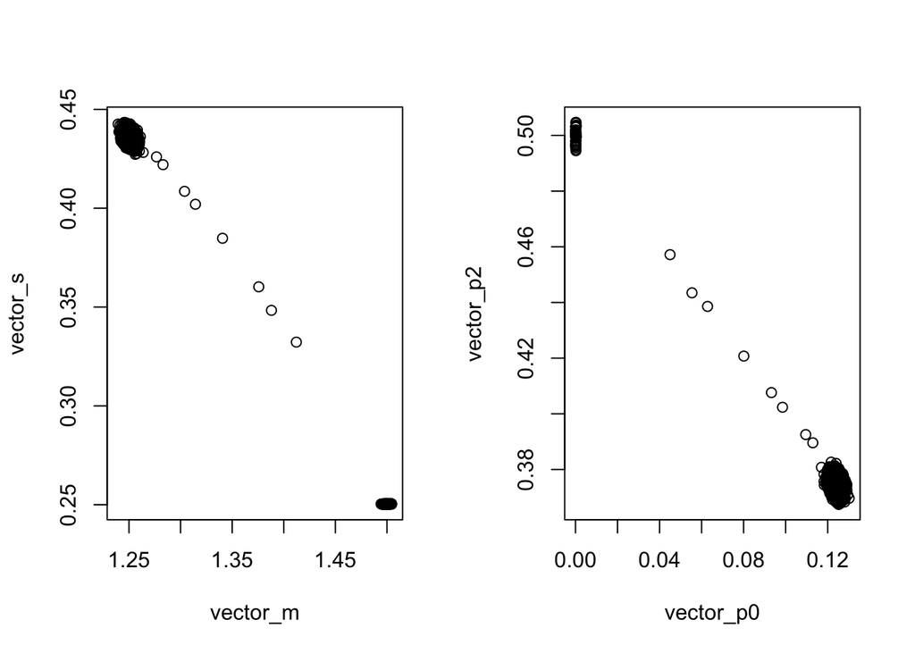

```r
par(mfrow = c(1,2))
plot(vector_m,vector_s)
plot(vector_p0,vector_p2)
```

## 5. Plot m against s and use the pedigree information of the YRI06.raw file to label the data points in the scatterplot. Recall that column 3 and 4 from the YRI06.raw contain information about the family relationship of the participants. Create two labels: one for individuals that have a parent-offspring relationship and another one for unrelated individuals. Comment on the results.

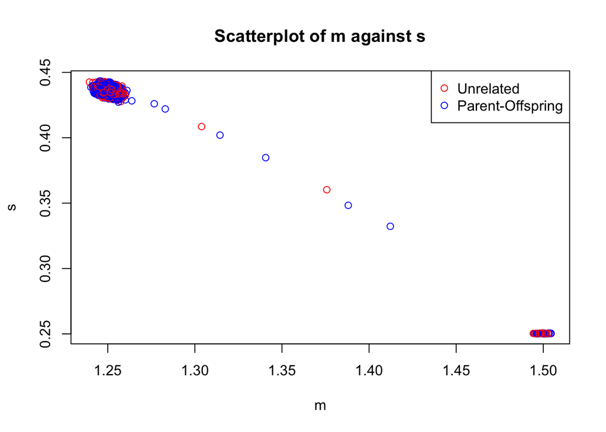

```r
labels <- ifelse(data[,3] != 0 & data[,4] != 2, "Parent-Offspring", "Unrelated")
plot(vector_m,vector_s, xlab = "m", ylab = "s", main = "Scatterplot of m against s", col = ifelse(labels == "Parent-Offspring", "red", "blue"))
legend("topright", legend = unique(labels), col = c("red", "blue"), pch = 1)
```

The results show that the conclusion made in the previous question to be not entirely true. As you can see both Unrelated and Parent-Offspring relationships either with m equal to 1.25 and 1.50.

## 6. Use the package SNPRelate to estimate the IBD probabilities, and plot the probabilities of sharing 0 and 1 IBD alleles (k0 and k1) for all pairs of individuals. Use the pedigree information of the YRI06.raw file to label the data points in the scatterplot (same as before, one colour for parent-offspring relationship and another colour for unrelated individuals).

```r
snpgdsCreateGeno("YRI6.gds", genmat = as.matrix(alleles), snp.id = names(alleles), sample.id = data$IID, snpfirstdim=FALSE)
genofile <- snpgdsOpen("YRI6.gds")
snpset <- snpgdsLDpruning(genofile, ld.threshold=0.2)
```

```
## SNP pruning based on LD:
## Excluding 0 SNP on non-autosomes
## Excluding 0 SNP (monomorphic: TRUE, MAF: NaN, missing rate: NaN)
##     # of samples: 84
##     # of SNPs: 56,574
##     using 1 thread
##     sliding window: 500,000 basepairs, Inf SNPs
##     |LD| threshold: 0.2
##     method: composite
## Chromosome 1: 0.12%, 69/56,574
## 69 markers are selected in total.
```

```r
snpset.id <- unlist(unname(snpset))
ibd <- snpgdsIBDMLE(genofile,maf=0.05, missing.rate=0.05,snp.id=snpset.id, num.thread=2)
```

```
## Identity-By-Descent analysis (MLE) on genotypes:
## Excluding 56,505 SNPs (non-autosomes or non-selection)
## Excluding 0 SNP (monomorphic: TRUE, MAF: 0.05, missing rate: 0.05)
##     # of samples: 84
##     # of SNPs: 69
##     using 2 threads
## MLE IBD:    the sum of all selected genotypes (0,1,2) = 5326
## MLE IBD: Tue Dec 19 11:05:20 2023    0%
## MLE IBD: Tue Dec 19 11:05:20 2023    100%
```

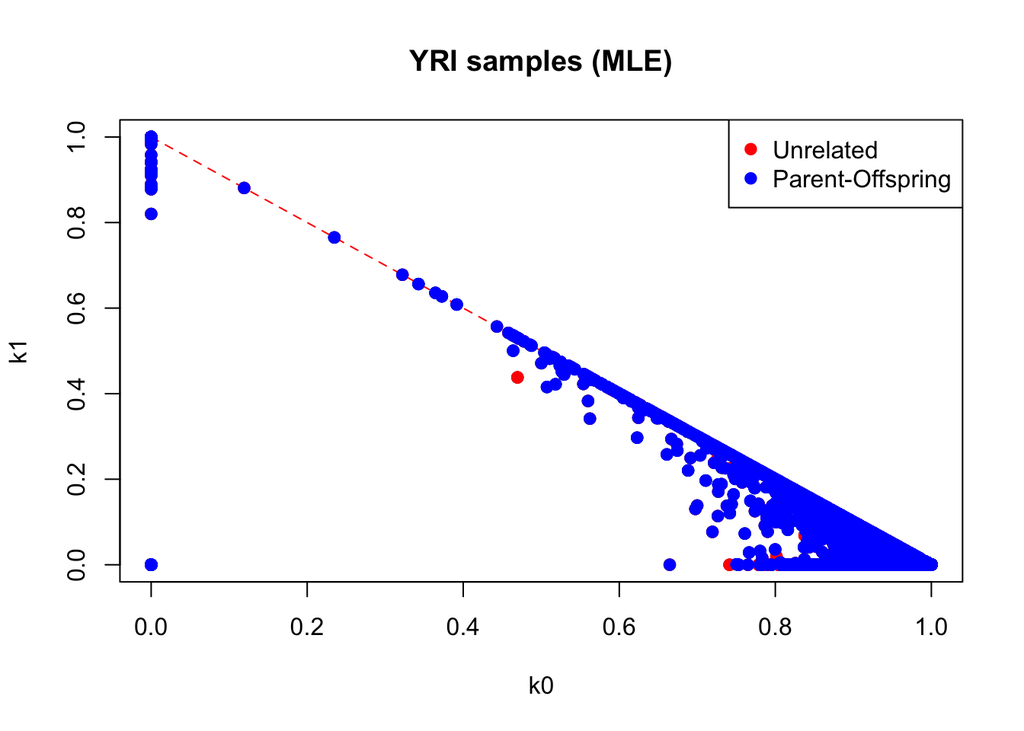

```r
ibd.coeff <- snpgdsIBDSelection(ibd)


labels <- ifelse(data[,3] != 0 & data[,4] != 2, "Parent-Offspring", "Unrelated")

plot(ibd.coeff$k0, ibd.coeff$k1, xlim=c(0,1), ylim=c(0,1),
 xlab="k0", ylab="k1", main="YRI samples (MLE)")
lines(c(0,1), c(1,0), col="red", lty=2)

points(ibd$k0[labels == "Parent-Offspring"], ibd$k1[labels == "Parent-Offspring"], col = "red", pch = 19)
points(ibd$k0[labels == "Unrelated"], ibd$k1[labels == "Unrelated"], col = "blue", pch = 19)

legend("topright", legend = unique(labels), col = c("red", "blue"), pch = 19)
```

## 7. Do you think the family relationships between all individuals were correctly specified?

The family relationships between individuals are correctly specified for the ones with k0=0, but when k0>0 and k1 is more or less 0, the relationship would have to be Unrelated. When k0>0 and k1>0 there can be Parent-Offspring relationship but there would have to be more Unrelated relationships. When k0=0 and k1=0, the relationship is monozygotic twins.